# ITNPBD2 Assignment - Project Gutenberg Analysis

# Executive Summary

Project Gutenberg is an open-source repository that holds notable old literature works; thus, an analysis of the works from the library would provide some insight into the trends and correlations of old literature and help to distinguish it from modern publications. A metadata of essential information was created, together with an analysis of the overall trend in book length of each book, and the ratio of book length to unique word count was the first phase of the analysis. In the second phase, a few books by a randomly chosen author were examined to determine if there were any patterns in the author's usage of vocabulary, sentiment, similarity in writing, and genre. To compare the writing styles of two authors from the same or different eras, books by different writers were reviewed as part of phase three of the analysis. This evaluation was based on the factors indicated in phase II. According to analyses, authors usually stick to their favourite genres; as an example, from our analysis, W.W. Jacob's writings skewed towards fiction, while Sir Arthur Quiller's works were poems. Additionally, there aren't any significant differences in the book's intentions and polarity of the books from same author. The target audience was also determined by analysing the book's complexity.

## [PHASE I] Creating the metadata

A project to digitise and archive literature, including novels, poems, short tales, and plays, named Project Gutenberg, is an online library of free eBooks. It includes artistic creations created from 1800 or later. In order to comprehend the trend of literary work and gain insight into the development of literature and authors, we are analysing some of the works in the Gutenberg library and the associated data.

Three steps will be taken to complete the analysis.

- Develop metadata to examine the relationship and trend in general information
- Examine books by a particular author
- Examine books from several authors

```python
from glob import glob
import pandas as pd
import os
import re
import nltk
import matplotlib.pyplot as plt
import string
from nltk.corpus import stopwords
from nltk.probability import FreqDist
from nltk.util import ngrams
from nltk.collocations import *
from nltk.sentiment import SentimentIntensityAnalyzer
import seaborn as sns
# nltk.download('vader_lexicon')
# nltk.download('punkt')
# nltk.download('stopwords')
# nltk.download('omw-1.4')
import spacy
nlp = spacy.load('en_core_web_lg')
import text2emotion as te
import seaborn as sns
import numpy as np
```

The following functions will convert the Python lists that will be generated in all the three phases into NumPy array, since NumPy arrays are efficient and compact, reading and storing large sets of data in arrays requires less memory and is more convenient to use while analysing the data. Moreover, according to [10], NumPy arrays outperform Python Lists approximately by a rate of 30x. However, strings are not transformed to NumPy strings np.str_() in our analysis, since it does not work well with some features and is not supported in spacy as well.

```python
def list_to_numpy_array(lst):
    return np.array(lst)
```

## Data Cleaning and Preparations

The bibliographic record in [1] (a representative sample of a book from the archive) served as the inspiration for the creation of metadata for the complete collection in the repository. What if we could gather all the essential details in one location?

Glob module and open() function has been used to read all the files, and to search a specific string, the regular expression libraries were used referring [2]–[3], and in order for the re function to search for the term and select the necessary phrase, each file has been searched based on the keyword that comes prior to it, such as "Title:", 'Author:' and so on. And the total word count and unique word count were then retrieved using the split() and len() functions, which has been stored in a list later and the combined data has been put together in a dataframe to make it more readable and accessible.

```python
authors_list = []
title_list = []
release_date = []
language_list = []
updated_date = []
word_count = []
total_unique_words = []


all_files = glob('1*')

for i in all_files:
    with open(f'{i}', 'r') as fid:
        f_read = fid.read()

        try:
            authors_search = re.search('Author: (.*?)\n', f_read).group(1)
            authors_list.append(authors_search)

        except:
            authors_search = re.search('Author: (.*?)\n', f_read)
            authors_list.append(authors_search)

        try:
            title_search = re.search('Title: (.*?)\n', f_read).group(1)
            title_list.append(title_search)
        except:
            title_search = re.search('Title: (.*?)\n', f_read)
            title_list.append(title_search)

        try:
            release_date_search = re.search('Release Date: (.*?)\n', f_read).group(1)
            release_date.append(release_date_search)
        except:
            release_date_search = re.search('Release Date: (.*?)\n', f_read)
            release_date.append(release_date_searchdate)

        try:
            language_search = re.search('Language: (.*?)\n', f_read).group(1)
            language_list.append(language_search)
        except:
            language_search = re.search('Language: (.*?)\n', f_read)
            language_list.append(language_search)

        try:
            updated_date_search = re.search('Last updated: (.*?)\n', f_read).group(1)
            updated_date.append(updated_date_search)
        except:
            updated_date_search = re.search('Last updated: (.*?)\n', f_read)
            updated_date.append(updated_date_search)

            total_words = f_read.split()
            total_words_count = len(total_words)
            word_count.append(total_words_count)
            unique_words = len(set(total_words))
            total_unique_words.append(unique_words)



for index, i in enumerate(release_date):
    try:
        updated_release = i[:-15]
        release_date[index] = updated_release
    except:
        release_date[index] = None
```

```python
authors_array = list_to_numpy_array(authors_list)
title_array = list_to_numpy_array(title_list)
release_date_array = list_to_numpy_array(release_date)
language_array = list_to_numpy_array(language_list)
updated_date_array = list_to_numpy_array(updated_date)
word_count_array = list_to_numpy_array(word_count)
total_unique_words_array = list_to_numpy_array(total_unique_words)
```

The data frame has been provided a dictionary that has been created with the lists as values and the key being the title name. To address the problem with unequal arrays, such as word count and unique word count, [4] has been referred. A bigger dataset was specifically considered when designing this, which might later be enhanced with additional features that are considered from a wider angle.

```python
dict_of_features_list = {'title': title_array, 'author': authors_array, 'book length': word_count_array,
                         'unique words': total_unique_words_array, 'published on': release_date_array,
                         'updated date': updated_date_array,
                         'language': language_array}

dict_of_features_list = dict([(x, pd.Series(y)) for x, y in
                              dict_of_features_list.items()])
df = pd.DataFrame(dict_of_features_list)
df.head(5)
# df.to_csv('dataframe.csv', encoding='utf-8')
```

|  | title | author | book length | unique words | published on | updated date | language |
| --- | --- | --- | --- | --- | --- | --- | --- |
| 0 | Apocolocyntosis | Lucius Seneca | 8807.0 | 3035.0 | November 10, 2003 | None | English |
| 1 | The House on the Borderland | William Hope Hodgson | 64594.0 | 10832.0 | November 10, 2003 | January 19, 2009 | English |
| 2 | My First Years As A Frenchwoman, 1876-1879 | Mary King Waddington | 51300.0 | 11263.0 | November 10, 2003 | None | English |
| 3 | The Warriors | Lindsay, Anna Robertson Brown | 73656.0 | 12857.0 | November 10, 2003 | None | English |
| 4 | A Voyage to the Moon | George Tucker | 16512.0 | 4538.0 | November 7, 2003 | None | English |

```python
df.info()
```

```
<class 'pandas.core.frame.DataFrame'>
RangeIndex: 1176 entries, 0 to 1175
Data columns (total 7 columns):
 #   Column        Non-Null Count  Dtype
---  ------        --------------  -----
 0   title         1176 non-null   object
 1   author        1171 non-null   object
 2   book length   1153 non-null   float64
 3   unique words  1153 non-null   float64
 4   published on  1176 non-null   object
 5   updated date  23 non-null     object
 6   language      1176 non-null   object
dtypes: float64(2), object(5)
memory usage: 64.4+ KB
```

```python
df[df.duplicated()]
```

|  | title | author | book length | unique words | published on | updated date | language |
| --- | --- | --- | --- | --- | --- | --- | --- |
| 1159 | The Mirror of Literature, Amusement, and Instr... | Various | NaN | NaN | March 8, 2004 | None | English |
| 1161 | The Mirror of Literature, Amusement, and Instr... | Various | NaN | NaN | March 8, 2004 | None | English |
| 1162 | The Mirror of Literature, Amusement, and Instr... | Various | NaN | NaN | March 8, 2004 | None | English |

```python
df.drop_duplicates(inplace=True)
df[df.duplicated()]
```

|  | title | author | book length | unique words | published on | updated date | language |
| --- | --- | --- | --- | --- | --- | --- | --- |

The next step in our data cleaning procedure will be identifying the null values using the isnull() method, which will substitute the NULL with a Boolean value of True else False. The null values are represented by the highlighted region of the heatmap, and their removal will be the next step in the cleaning process. This heatmap was created to provide a clear overview of all the missing values.

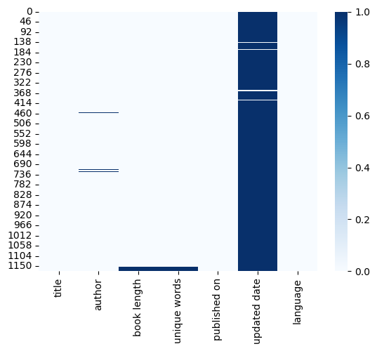

```python
df.isnull().sum()
sns.heatmap(df.isnull(), cmap='Blues')
```

The "updated date" has the highest percentage of null values in the entire dataset, as shown by the heatmap, therefore deleting it will be the next step. Using the drop() method, the dataset's "updated date" column will be completely removed. It's noteworthy that a book's publication year might provide some insight into the evolution of literature and its creators.

```python
df.drop('updated date',axis=1,inplace=True)
df.head(2)
```

|  | title | author | book length | unique words | published on | language |
| --- | --- | --- | --- | --- | --- | --- |
| 0 | Apocolocyntosis | Lucius Seneca | 8807.0 | 3035.0 | November 10, 2003 | English |
| 1 | The House on the Borderland | William Hope Hodgson | 64594.0 | 10832.0 | November 10, 2003 | English |

The "updated date" column has been removed; however, the columns with the author, book length, and unique words data still include a limited handful of null entries. To make our data ready for analysis, we will use the dropna() method to eliminate the last few rows with the null values, and by providing the inplace argument to True, the dataset will be updated with the changes.

```python
df.dropna(inplace=True)
```

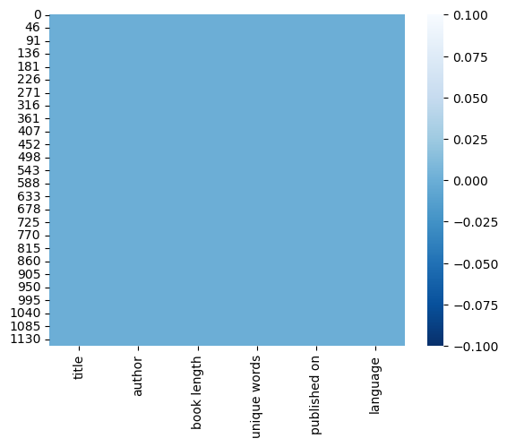

```python
sns.heatmap(df.isnull(), cmap='Blues_r')
```

Since our dataset is ready and all null values have been eliminated based on the heatmap, we will go ahead with additional exploratory analysis.

## Exploratory Data Analysis

```python
df.describe()
```

|  | book length | unique words |
| --- | --- | --- |
| count | 1148.000000 | 1148.000000 |
| mean | 60929.947735 | 10500.108885 |
| std | 59504.836592 | 7200.075778 |
| min | 3343.000000 | 1119.000000 |
| 25% | 16900.250000 | 5494.000000 |
| 50% | 47784.000000 | 9259.500000 |
| 75% | 87250.000000 | 14262.500000 |
| max | 984066.000000 | 99888.000000 |

A description of the numerical data in our dataset, comprising book length and unique word count, has been analysed and compiled using the describe() method. The average word count per book in our collection is 60,929, however, there are 10,500 unique words for each book on average. Our dataset contains 1148 books, with the shortest book having 3343 words and the longest having 984066. The longest one should be classified as a novel, whereas poems often have a shorter length. It will also be intriguing to see how our book's book lengths are dispersed.

##### Q1 - Finding out which category of book length the books in our dataset belong to would be interesting.

We sorted the data by author to determine which authors had the most and fewest books in the repository, which may help us determine the period of authors to further investigate. The value_counts() function counts the instances in which an author appears in the data and returns the count value. In addition, the sort_values() method sorts the results in descending order to return the author with the most books and printed the top 10 results for a brief overview.

```python
df['author'].value_counts().sort_values(ascending=False)[:10]
```

```
Various                 191
W.W. Jacobs              52
Roger McGuinn            30
Anonymous                30
Charles Kingsley         14
John Lord                14
Unknown                  11
James D. Richardson       8
Richard Le Gallienne      7
Arthur Schopenhauer       7
Name: author, dtype: int64
```

The author name 'various' has appeared the most in the dataset, which represents multiple authors with 191 books. WW Jacobs has appeared in 52 books, while 30 books have been published anonymously lacking author information and 11 publications have unidentified writers. Assessing the trend in book counts for well-known authors and learning how many authors have so far only published one book would be interesting.

##### Q2 - It would be noteworthy to analyse the fraction of authors who have just one or two books to their credit and the overall book count trend.

## Descriptive Analytics

#### Q1 - The statistical analysis of book length and the proportion of original words in the books would be noteworthy.

Readers anticipate a certain word count for each genre, which is just the length of the book. A short story has fewer words than 20,000 while novels will always be lengthier (more than 80,000 words). This information will assist in determining who the work is appropriate for. Hence it will interesting to get a statistics on the word counts of books in our dataset. The correlation function corr() has been used to determine the relationship of book length to the unique words and the joint plot graph has been utilized to examine the trend in the books with regard to the two variables, book length and word count.

```python
df.corr().style.background_gradient(cmap='Blues_r')
```

|  | book length | unique words |
| --- | --- | --- |
| book length | 1.000000 | 0.902336 |
| unique words | 0.902336 | 1.000000 |

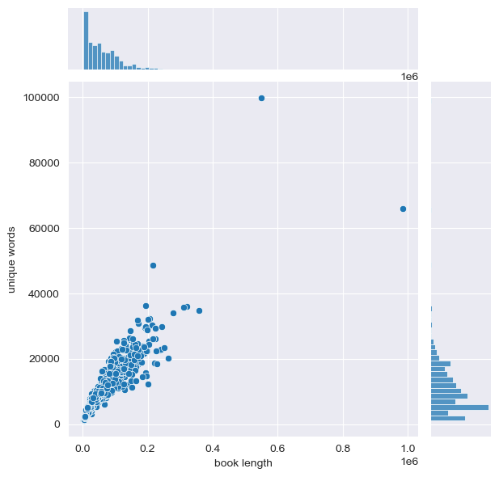

```python
plt.figure(figsize=(10,7))
sns.set_style('darkgrid')
sns.jointplot(x='book length',y='unique words',data=df,kind='scatter', palette='Blues')
```

#### Q2 - It would be noteworthy to analyse the fraction of authors who have just one or two books to their credit and the overall book count trend.

When writings are evaluated using data on the author, audience, bias, purpose, context, and the date the work was created, it becomes possible to see how writing has changed over time and forecast what will come out next. The count plot, which represents the number of repeating authors in our dataset, has been used to illustrate the authors to book ratio.

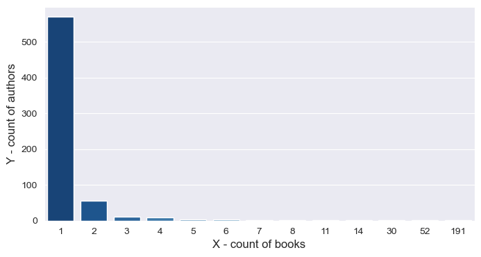

```python
fig, ax = plt.subplots(figsize=(8,4))
sns.countplot(x=df['author'].value_counts(), data=df, palette='Blues_r')
ax.set_ylabel('Y - count of authors', fontsize=12)
ax.set_xlabel('X - count of books', fontsize=12)
```

Examining the number of books written by each author, W.W. Jacobs stands out and has been chosen at random, as the author has owned the most books as a person in our dataset (see below for a comprehensive list of authors publications and other information) which will aid us dig deeper into the publishing period, language and other details. The authors data from our dataset was explicitly searched using the method.str.contains() with author name as the search argument. For additional analysis, the top 10 findings have been printed.

```python
df[df['author'].str.contains('W.W. Jacobs', na=False)][:10]
```

|  | title | author | book length | unique words | published on | language |
| --- | --- | --- | --- | --- | --- | --- |
| 360 | Fine Feathers | W.W. Jacobs | 7090.0 | 2251.0 | January 1, 2004 | English |
| 361 | Friends In Need | W.W. Jacobs | 49570.0 | 9118.0 | January 1, 2004 | English |
| 362 | Good Intentions | W.W. Jacobs | 237522.0 | 22729.0 | January 1, 2004 | English |
| 363 | Fairy Gold | W.W. Jacobs | 58262.0 | 10415.0 | January 1, 2004 | English |
| 364 | Watch-Dogs | W.W. Jacobs | 53070.0 | 8439.0 | January 1, 2004 | English |
| 365 | The Bequest | W.W. Jacobs | 60408.0 | 12910.0 | January 1, 2004 | English |
| 366 | The Guardian Angel | W.W. Jacobs | 49085.0 | 7923.0 | January 1, 2004 | English |
| 367 | Dual Control | W.W. Jacobs | 27300.0 | 5575.0 | January 1, 2004 | English |
| 368 | Skilled Assistance | W.W. Jacobs | 60867.0 | 10368.0 | January 1, 2004 | English |
| 369 | For Better or Worse | W.W. Jacobs | 16153.0 | 3389.0 | January 1, 2004 | English |

The surprising result from the aforementioned data is that, rather than the book's actual publishing date, the published date contains the date that Gutenberg released the book, which restricts us from identifying when the book was created or analysing literature based on the era. As a result, there is not enough data in the data frame to analyse how the literature has developed. However, because the information is dispersed and lacks a consistent format, the exact publication date can be determined using advanced analytics.

## [PHASE II] Analysis of the books based on author

Given that the dataset contains multiple books written by the few author, the assessment has now been split into two phases.

- Analyze 3 books written by an author to understand their trend, writing style, and so forth.
- Compare the books by two different authors to see if they share the same trend.

Throughout the report, the following functions() will be used to open files that are meant to,

- book_search_by_author_name(author_name) will search a book by author name.
  - In the function .txt format files will be searched in the current directory using the os.getcwd() method. Once the.txt files are searched, it will scan for the authors name, and if it is present, the file name will be returned, which will be used in subsequent stages to search a keyword in the data files.
- open_book_by_file_name(book_num) will Read a book where the file name itself serves as the book number argument.
  - The book is searched and opened using the open() function and read by the readlines() method, which is converted to an array, and the irrelevant introduction and licencing information will be removed using the del() function to make the text less cluttered and prepare for our research. After the lines are deleted, each item is concatenated and converted back to a single string for further analysis.

```python
def book_search_by_author_name(author_name):
    here = os.getcwd()
    for file in os.listdir(here):
        if file.endswith('.txt'):
            read_file = open(here + "/" + file, 'r')
            if author_name in read_file.read():
                keyword_list = list_to_numpy_array(file)
                print(keyword_list, end=' ')


def open_book_by_file_name(book_num):
    with open(f'{book_num}.txt', 'r') as fid:
        lines = fid.readlines()
        del lines[:7]
        del lines[-400:]
        del lines[8:14]
        text_in_string = ' '.join([i for i in lines])
        return text_in_string
```

## [PHASE II-A] Comparison of books by the same author

The list of W.W. Jacobs' published works has been searched using the aforementioned function to get started, and three random books have been chosen from the results for the analysis. Other writers' books will be searched for using a similar procedure in the subsequent stages, and any random keywords can also be used to search for books.

```python
print(book_search_by_author_name('Author: W.W. Jacobs'))
```

```
10561.txt 10562.txt 10563.txt 10564.txt 10565.txt 10566.txt 10567.txt 10568.txt 10569.txt 10570.txt 10571.txt 10572.txt 10573.txt 10781.txt 10782.txt 10783.txt 10784.txt 10785.txt 10786.txt 10787.txt 10788.txt 10789.txt 10790.txt 10791.txt 10792.txt 10871.txt 10872.txt 10873.txt 10874.txt 10875.txt …
```

Three books have been randomly selected from the list above, and these three will be examined during the study. Three books, 10562.txt, 10783.txt, and 11472.txt (filenames), have been chosen and saved in the variables named book1, book2, and book3, where a few lines from each sample have been printed below for reference.

```python
book1 = open_book_by_file_name(10562)
print(book1[:80])
```

```
 Title: Friends In Need
        Ship's Company, Part 2.

 Author: W.W. Jacobs
```

```python
book2 = open_book_by_file_name(10783)
print(book2[:80])
```

```
 Title: Self-Help
        Sailor's Knots, Part 4.

 Author: W.W. Jacobs

 Rel
```

```python
book3 = open_book_by_file_name(11472)
print(book3[:80])
```

```
 Title: Paying Off
        Deep Waters, Part 2.

 Author: W.W. Jacobs

 Relea
```

## Data Cleaning and Preparations

The sections will clean and process the text data using the functions() listed below. Using the aforementioned function open_book_by_file_name(); it will read the book and alter the text's case with lower() method and search for the keyword "http" to replace the hyperlinks with a blank space using regular expressions, create sentence tokens and a list of word tokens using nltk tokenization, and thereafter remove all stop words as the final step in the process to capture precise data. The article [8] has been referred for learning about eliminating stopwords, and [9] has been referred for learning about the isalpha() method, which will aid in keeping alphabetic characters and deleting unnecessary characters, making the procedure less tedious. Finally, the lists were transformed into a NumPy array to provide a compact and efficient result to be used in the future.

```python
def cleaned_data(book_num):
    # removed hyperlinks
    remove_hyperlink = re.sub(r'http\S+', '', open_book_by_file_name(book_num), flags=re.MULTILINE)
    # converted to lowercase text
    lowercase_text = remove_hyperlink.lower()
    # The words would, could are replaced to avoid any complication in following steps
    clean_text = lowercase_text.replace(':', ' ').replace(',', ' ').replace('?', ' ').replace('!', ' ').replace('*',
                                                                                                                '').replace(
        '-', ' ').replace('.', ' ').replace(';', ' ').replace("''", ' ').replace("``", ' ').replace(":", ' ').replace(
        "'s", " ").replace('would', " ").replace('could', ' ')
    return clean_text


def sentence_tokens(book_num):
    # sentence tokenization
    token_sentence = nltk.sent_tokenize(cleaned_data(book_num))
    token_sentence_array = list_to_numpy_array(token_sentence)
    return token_sentence_array


def word_tokens(book_num):
    # word tokenization
    token_word = nltk.word_tokenize(cleaned_data(book_num))
    words_list = [x for x in token_word if x.isalpha()]
    words_list_array = list_to_numpy_array(words_list)
    return words_list_array


def remove_stopwords(word_tokens_list):
    # remove stopwords using nltk stopwords
    processed_token_words = [x for x in word_tokens_list if x not in stopwords.words('english')]
    processed_token_words_array = list_to_numpy_array(processed_token_words)
    return processed_token_words_array
```

## Exploratory Data Analysis

The consol_book_data() function will print the cleaned data as a string, sentence and word tokens, and the tokens after stopword removal; and the function consol_book_features(), will return the word counts, lexical diversity, frequently used keywords, and frequently occured bigrams in a dictionary, which will aid in the analysis of the data in subsequent stages. The cleaned data is not kept in any variables to reduce clutter and further complexity, however for readability, each data cleaning process has been printed in the subsequent phases.

The len() function counts the total words to produce the book length from the cleaned text string; the total word count has been gathered by counting the word tokens, and set() will store the unique words, which were later tallied. The frequently occurring words and word pairs have been identified using FreqDist() function.

```python
def consol_book_data(book_num):
    print(f'The data after inital cleaning:\n {cleaned_data(book_num)[:45]}', '\n')
    print(f'After Sentence tokenization:\n {sentence_tokens(book_num)[0][:25]}', '\n')
    print(f'Tokenized words:\n {word_tokens(book_num)[:25]}', '\n')
    word_tokens_list_1 = word_tokens(book_num)
    print(f'After removing stopwords:\n {remove_stopwords(word_tokens_list_1)[:10]}', '\n\n')


def consol_book_features(book_num):
    word_tokens_list_1 = word_tokens(book_num)
    book_length = len(cleaned_data(book_num))
    total_words_count = len(remove_stopwords(word_tokens_list_1))
    unique_words_count = len(set(remove_stopwords(word_tokens_list_1)))
    lex_div = unique_words_count / total_words_count
    f_dist = FreqDist(remove_stopwords(word_tokens_list_1))
    freq_bigrams = FreqDist(list(nltk.bigrams(remove_stopwords(word_tokens_list_1))))

    dict_of_book_features = {'book length': book_length, 'word count': total_words_count,
                            'unique word count': unique_words_count, 'lexical diversity': lex_div,
                            'frequent words': f_dist, 'frequent bigrams': freq_bigrams}
    return dict_of_book_features
```

```python
consol_book_data(10562)
book1_features = consol_book_features(10562)
print(f'The features of Book 1:\n {book1_features}')
```

```
The data after inital cleaning:

 title  friends in need
        ship  compan

After Sentence tokenization:

 title  friends in need


Tokenized words:
 ['title' 'friends' 'in' 'need' 'ship' 'company' 'part' 'author' 'w' 'w'
 'jacobs' 'release' 'date' 'january' 'ebook' 'produced' 'by' 'david'
 'widger' 'ship' 'company' 'by' 'w' 'w' 'jacobs']

After removing stopwords:
 ['title' 'friends' 'need' 'ship' 'company' 'part' 'author' 'w' 'w'
 'jacobs']


The features of Book 1:
 {'book length': 22206, 'word count': 2024, 'unique word count': 902, 'lexical diversity': 0.44565217391304346, 'frequent words': FreqDist({'mr': 123, 'said': 101, 'kidd': 59, 'gibbs': 55, 'brown': 35, 'mrs': 19, 'wot': 18, 'go': 16, 'joe': 13, 'back': 13, ...}), 'frequent bigrams': FreqDist({('said…
```

```python
consol_book_data(10783)
book2_features = consol_book_features(10783)
print(f'The features of Book 2:\n {book2_features}')
```

```
The data after inital cleaning:

 title  self help
        sailor  knots  par

After Sentence tokenization:

 title  self help


Tokenized words:
 ['title' 'self' 'help' 'sailor' 'knots' 'part' 'author' 'w' 'w' 'jacobs'
 'release' 'date' 'january' 'ebook' 'produced' 'by' 'david' 'widger'
 'sailors' 'knots' 'by' 'w' 'w' 'jacobs' 'self']

After removing stopwords:
 ['title' 'self' 'help' 'sailor' 'knots' 'part' 'author' 'w' 'w' 'jacobs']


The features of Book 2:
 {'book length': 20654, 'word count': 1797, 'unique word count': 742, 'lexical diversity': 0.4129104062326099, 'frequent words': FreqDist({'ses': 86, 'sam': 66, 'ginger': 55, 'peter': 29, 'wot': 24, 'arter': 21, 'e': 19, 'got': 19, 'put': 16, 'man': 15, ...}), 'frequent bigrams': FreqDist({('ses', '…
```

##### Q3 - Now that the most frequent word list seems promising, it would be fascinating to examine the word usage ratio and try to make conclusions from it.

##### Q4 - It would also be intriguing to look at the relationships between the often occurring word combinations in the list and how they are used in the text.

```python
consol_book_data(11472)
book3_features = consol_book_features(11472)
print(f'The features of Book 3:\n {book3_features}')
```

```
The data after inital cleaning:

 title  paying off
        deep waters  part

After Sentence tokenization:

 title  paying off


Tokenized words:
 ['title' 'paying' 'off' 'deep' 'waters' 'part' 'author' 'w' 'w' 'jacobs'
 'release' 'date' 'march' 'ebook' 'produced' 'by' 'david' 'widger' 'deep'
 'waters' 'by' 'w' 'w' 'jacobs' 'paying']

After removing stopwords:
 ['title' 'paying' 'deep' 'waters' 'part' 'author' 'w' 'w' 'jacobs'
 'release']


The features of Book 3:
 {'book length': 18692, 'word count': 1582, 'unique word count': 603, 'lexical diversity': 0.3811630847029077, 'frequent words': FreqDist({'ses': 59, 'wot': 33, 'e': 23, 'george': 22, 'five': 20, 'like': 19, 'got': 19, 'one': 19, 'see': 19, 'two': 18, ...}), 'frequent bigrams': FreqDist({('five', 'b…
```

##### Q5 - Evaluating the complexity of the literature will be a fascinating aspect of the analysis, as it could contribute to a better understanding of people, experiences and culture in the author's era.

##### Q6 - Can we identify and compare the sentiment score and emotions in the book to the next ones by the same or different authors?

Now that we have the word count and frequently repeated terms in each of our books, let's attempt to figure out how many parts of speech are contained in each book. nltk.pos_tag() from nltk library has been used to tag the parts of speech to each of the word tokens we have produced in our data cleaning process.

```python
def pos_tag(book_num):
    pos_tagged_words = nltk.pos_tag(word_tokens(book_num))
    pos_tag_to_array = list_to_numpy_array(pos_tagged_words)
    return pos_tag_to_array
```

```python
pos_tag_book1 = pos_tag(10562)
pos_tag_book2 = pos_tag(10783)
pos_tag_book3 = pos_tag(11472)

print(f'The POS tagging for Book 1 is : {pos_tag_book1[:3]}')
print(f'The POS tagging for Book 2 is : {pos_tag_book2[:3]}')
print(f'The POS tagging for Book 3 is : {pos_tag_book3[:3]}')
```

```
The POS tagging for Book 1 is : [['title' 'NN']
 ['friends' 'NNS']
 ['in' 'IN']]
The POS tagging for Book 2 is : [['title' 'NN']
 ['self' 'PRP']
 ['help' 'VBP']]
The POS tagging for Book 3 is : [['title' 'NN']
 ['paying' 'VBG']
 ['off' 'RP']]
```

In the review results, singular nouns are represented by NN; plural nouns are represented by NNS; present participle verbs are represented by VBG and so on. In later stages, similarity check and complexity analysis will be performed by referring to the data.

##### Q7 Earlier, we were able to analyse the frequently used words and attempt to determine their relationship. Is it also possible to find textual similarities in the author's books?

## Descriptive Analytics

#### Q3 - Now that the most frequent word list seems promising, it would be fascinating to examine the word usage ratio and try to make conclusions from it.

It's an intriguing fact to discover whether the most frequently used words reveal any outstading or the key idea in the book. As well as the ratio of the top most frequently used words is worth comaparing. The frequently occuring word tokens from the cleaned data has been taken using the frequency distribution function for the analysis. The frequently used terms in the aforementioned steps are graphically represented using the plot() function.

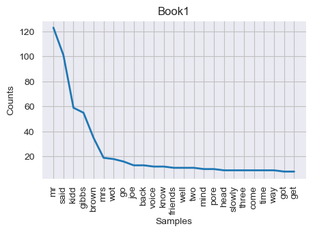

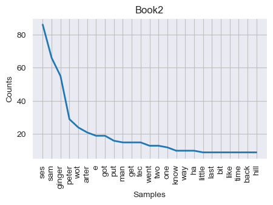

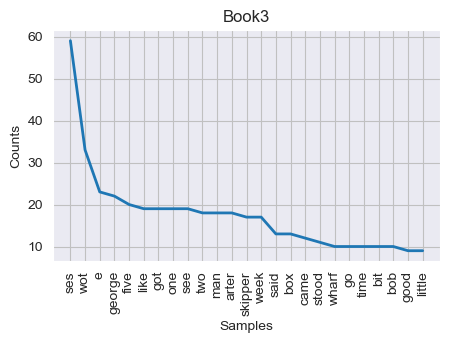

```python
plt.figure(figsize=(5,3))
book1_features['frequent words'].plot(25, title='Book1')
plt.figure(figsize=(5,3))
book2_features['frequent words'].plot(25, title='Book2')
plt.figure(figsize=(5,3))
book3_features['frequent words'].plot(25, title='Book3')
```

#### Q4 - It would also be intriguing to look at the relationships between the often occurring word combinations in the list and how they are used in the text.

It would be useful to break words into pairs of two, analyse how well they relate to one another, and find the common pair. Bigram in nltk has been been used to generate the word pairs, and the most frequently occurred word pairs were selected for analysis. The frequent bigram values gathered from the book characteristics dictionary during exploratory analysis have been used to plot the bigram correlation of the top 25 frequent word pairs.

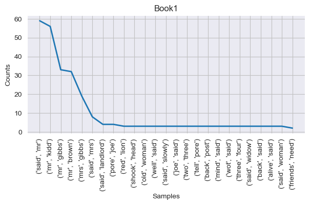

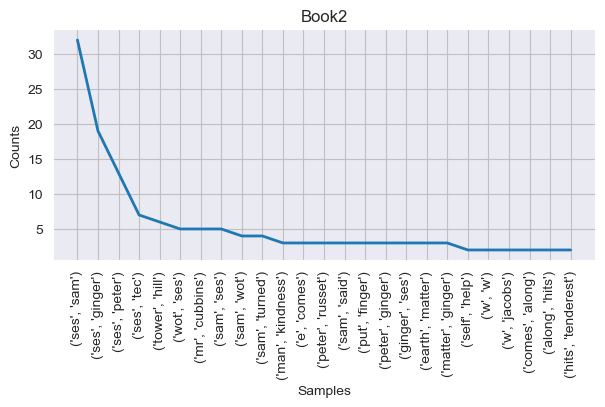

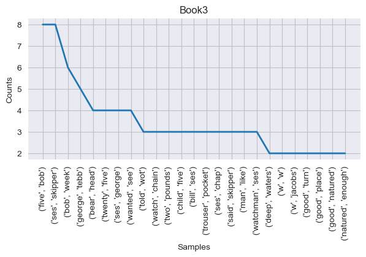

```python
plt.figure(figsize=(7,3))
book1_features['frequent bigrams'].plot(25, title='Book1')
plt.figure(figsize=(7,3))
book2_features['frequent bigrams'].plot(25, title='Book2')
plt.figure(figsize=(7,3))
book3_features['frequent bigrams'].plot(25, title='Book3')
```

#### Q5 - Evaluating the complexity of the literature will be a fascinating aspect of the analysis, as it could contribute to a better understanding of people, experiences and culture in the author's era.

Lexical density (the ratio of phrases to the total word count) reveals the text's complexity since it indicates whether it is appropriate for a specific language and demonstrates how complex the text is as it uses more nouns and phrases to express specific meaning. As a result, knowing that a book is short, its lexical density will help us determine its complexity as well. The lexical density has been determined by comparing the fraction of pos-tagged words to the overall number of words in the book.

```python
def lex_density(book_num):
    pos_count = len(pos_tag(book_num))
    lex_density_value = (pos_count/consol_book_features(book_num)['book length'])*100
    return lex_density_value
```

```python
print(f'The lexical density of Book 1 is : {lex_density(10562)}')
print(f'The lexical density of Book 2 is : {lex_density(10783)}')
print(f'The lexical density of Book 3 is : {lex_density(11472)}')
```

```
The lexical density of Book 1 is : 17.144015131045663
The lexical density of Book 2 is : 17.822213614796166
The lexical density of Book 3 is : 18.64968970682645
```

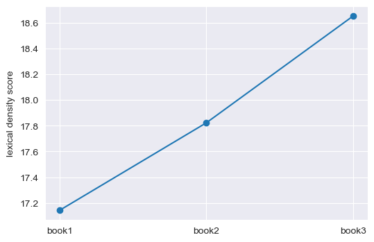

```python
lex_density_dict_ph1 = {'book1' : lex_density(10562), 'book2': lex_density(10783), 'book3' : lex_density(11472)}

fig, ax = plt.subplots(figsize=(6, 4))
ax.plot(lex_density_dict_ph1.keys(), lex_density_dict_ph1.values())
ax.scatter(lex_density_dict_ph1.keys(), lex_density_dict_ph1.values())
ax.set_ylabel('lexical density score')
```

In order to determine in which age group the book will be most popular, characteristics like lexical density (a measure of the book's complexity) and length of the book are relevant. By comparing the scores of the three works, we can determine that the complexity of the books is comparably lower, which may be because fewer descriptives or phrases are used. Therefore, a lower lexical density score may lead to the conclusion that the book is likely to be less complicated or descriptive and also suitable for a lower age bracket as well.

#### Q6 - Can we identify and compare the sentiment score and emotions in the book to the next ones by the same or different authors?

A book's sentiment score will give us a general idea of how positive or melancholy it is. Additionally, it will enable us to assess customer satisfaction. Therefore, it is interesting to match the sentiment scores of works by the same author or by various authors to ascertain their link. The vader sentiment intensity analyser is used to identify the polarity in the books.

```python
def sentiment_polarity_score(book_num):
    analyser = SentimentIntensityAnalyzer()
    polarity_score = analyser.polarity_scores(open_book_by_file_name(book_num))  # different author
    book_polarity = polarity_score
    return book_polarity
```

```python
senti_score_book1 = sentiment_polarity_score(10562)
print(f'The sentiment score of Book 1 is : {senti_score_book1}')

senti_score_book2 = sentiment_polarity_score(10783)
print(f'The sentiment score of Book 2 is : {senti_score_book2}')

senti_score_book3 = sentiment_polarity_score(11472)
print(f'The sentiment score of Book 3 is : {senti_score_book3}')
```

```
The sentiment score of Book 1 is : {'neg': 0.066, 'neu': 0.81, 'pos': 0.124, 'compound': 0.9998}
The sentiment score of Book 2 is : {'neg': 0.06, 'neu': 0.86, 'pos': 0.08, 'compound': 0.9976}
The sentiment score of Book 3 is : {'neg': 0.052, 'neu': 0.846, 'pos': 0.102, 'compound': 0.9996}
```

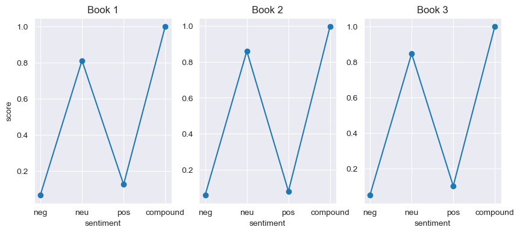

```python
fig, ax = plt.subplots(1, 3, figsize=(10, 4))

ax[0].plot(senti_score_book1.keys(), senti_score_book1.values())
ax[0].scatter(senti_score_book1.keys(), senti_score_book1.values())
ax[0].set_title('Book 1')
ax[0].set_ylabel('score')
ax[0].set_xlabel('sentiment')

ax[1].plot(senti_score_book2.keys(), senti_score_book2.values())
ax[1].scatter(senti_score_book2.keys(), senti_score_book2.values())
ax[1].set_title('Book 2')
ax[1].set_xlabel('sentiment')

ax[2].plot(senti_score_book3.keys(), senti_score_book3.values())
ax[2].scatter(senti_score_book3.keys(), senti_score_book3.values())
ax[2].set_title('Book 3')
ax[2].set_xlabel('sentiment')
```

Following an analysis of the results, we may conclude that all three of the author's works have sentiment scores that are comparably higher on the positive side than negative and that the compound score of 0.99 denotes overall positive sentiment. These figures can be used to analyse the author's readership and customer satisfaction levels and forecast idea of the upcoming works.

#### Q7 - Earlier, we were able to analyse the frequently used words and attempt to determine their relationship. Is it also possible to find textual similarities in the author's books?

The text similarity will give us information about how similarly an author writes his books, which may be used to anticipate the theme of the next book they will publish and the target audience, and also reveal how similarly authors write. Referring package spacy [6]–[7], I have performed a corpus-based text similarity assessment in the analysis. To check for similarity, the text string has been called as a spacy nlp object, which has been called at the start of the aanalysis. The pos tagging will be applied to the NLP object of the string. The words classified as a verb, noun, or adjectives will be selected using .pos *and lemmatized with .lemma* to obtain the root word, which will then be converted back to a string and analyzed for text similarity. To further explore the parallels based on them, we have gathered nouns, verbs, and adjectives. Below is a graphical representation of the combined results.

```python
def get_noun(data):
    book_noun = " ".join([word.lemma_ for word in data if word.pos_ == 'NOUN'])
    return nlp(book_noun)


def get_verb(data):
    book_verb = " ".join([word.lemma_ for word in data if word.pos_ == 'VERB'])
    return nlp(book_verb)


def get_adj(data):
    book_adj = " ".join([word.lemma_ for word in data if word.pos_ == 'ADJ'])
    return nlp(book_adj)
```

The Numpy array has been converted to string in the following section to feed in the nlp object of spacy, as spacy doesnt accept NumPy array numpy.str *and was getting the typeerror, "TypeError: Argument 'string' has incorrect type (expected str, got numpy.str*)"

```python
book1_sent = nlp(cleaned_data(10562))
book2_sent = nlp(cleaned_data(10783))
book3_sent = nlp(cleaned_data(11472))

print(f'The similarity in Book 1 and Book 2 is : {book1_sent.similarity(book2_sent)}')
print(f'The similarity in Book 1 and Book 3 is : {book1_sent.similarity(book3_sent)}')
print(f'The similarity of verbs used in Book 1 and Book 2 is : {get_verb(book1_sent).similarity(get_verb(book2_sent))}')
print(f'The similarity of nouns used in Book 2 and Book 3 is : {get_noun(book2_sent).similarity(get_noun(book3_sent))}')
```

```
The similarity in Book 1 and Book 2 is : 0.9821466260564634
The similarity in Book 1 and Book 3 is : 0.9584120148946079
The similarity of verbs used in Book 1 and Book 2 is : 0.9540406984693661
The similarity of nouns used in Book 2 and Book 3 is : 0.959085588541831
```

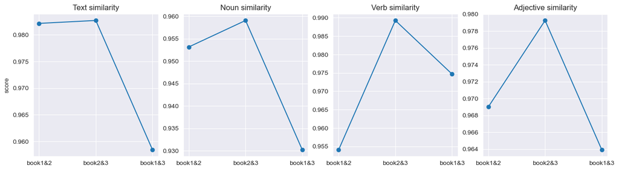

```python
noun_similarity_ph1 = {'book1&2': get_noun(book1_sent).similarity(get_noun(book2_sent)),
                       'book2&3': get_noun(book2_sent).similarity(get_noun(book3_sent)),
                       'book1&3': get_noun(book1_sent).similarity(get_noun(book3_sent))}

verb_similarity_ph1 = {'book1&2': get_verb(book1_sent).similarity(get_verb(book2_sent)),
                       'book2&3': get_verb(book2_sent).similarity(get_verb(book3_sent)),
                       'book1&3': get_verb(book1_sent).similarity(get_verb(book3_sent))}

adj_similarity_ph1 = {'book1&2': get_adj(book1_sent).similarity(get_adj(book2_sent)),
                      'book2&3': get_adj(book2_sent).similarity(get_adj(book3_sent)),
                      'book1&3': get_adj(book1_sent).similarity(get_adj(book3_sent))}

text_similarity_ph1 = {'book1&2': book1_sent.similarity(book2_sent), 'book2&3': book2_sent.similarity(book3_sent),
                       'book1&3': book1_sent.similarity(book3_sent)}

fig, ax = plt.subplots(1, 4, figsize=(16, 4))

ax[0].plot(text_similarity_ph1.keys(), text_similarity_ph1.values())
ax[0].scatter(text_similarity_ph1.keys(), text_similarity_ph1.values())
ax[0].set_title('Text similarity')
ax[0].set_ylabel('score')

ax[1].plot(noun_similarity_ph1.keys(), noun_similarity_ph1.values())
ax[1].scatter(noun_similarity_ph1.keys(), noun_similarity_ph1.values())
ax[1].set_title('Noun similarity')

ax[2].plot(verb_similarity_ph1.keys(), verb_similarity_ph1.values())
ax[2].scatter(verb_similarity_ph1.keys(), verb_similarity_ph1.values())
ax[2].set_title('Verb similarity')

ax[3].plot(adj_similarity_ph1.keys(), adj_similarity_ph1.values())
ax[3].scatter(adj_similarity_ph1.keys(), adj_similarity_ph1.values())
ax[3].set_title('Adjective similarity')
```

## [PHASE II-B] Comparison of books from different authors

As the third stage of the analysis, two books by random authors were chosen and compared to examine the literary and writing trends. To avoid repetition of the code, data cleaning will be done with functions() used in Part II-A, and a few lines from the books will be printed below for reference.

## Data Cleaning and Preparations

At this point in the analysis, the books 10869.txt and 10133.txt have been chosen and stored as books 4 and 5, respectively. The data has been read and processed using the functions defined in phase II-A.

```python
book4 = open_book_by_file_name(10869)
print(book4[:50])
```

```
 Title: The Abandoned Room

 Author: Wadsworth C
```

```python
book5 = open_book_by_file_name(10133)
print(book5[:110])
```

```
 Title: The Vigil of Venus and Other Poems by "Q"

 Author: Q
         (AKA: Sir Arthur Thomas Quiller-Couch
```

## Exploratory Data Analysis

Likewise, in phase II-A, we gathered the cleaned data, the book's features, and POS tags using the functions we developed there.

```python
consol_book_data(10869)
book4_features = consol_book_features(10869)
print(f'The features of Book 4 are:\n {book4_features}')
```

```
The data after inital cleaning:

 title  the abandoned room

 author  wadswo

After Sentence tokenization:

 title  the abandoned ro

Tokenized words:
 ['title' 'the' 'abandoned' 'room' 'author' 'wadsworth' 'camp' 'release'
 'date' 'january' 'ebook' 'language' 'english' 'produced' 'by' 'juliet'
 'sutherland' 'mary' 'meehan' 'and' 'the' 'online' 'distributed'
 'proofreading' 'team']

After removing stopwords:
 ['title' 'abandoned' 'room' 'author' 'wadsworth' 'camp' 'release' 'date'
 'january' 'ebook']


The features of Book 4 are:
 {'book length': 448731, 'word count': 37363, 'unique word count': 5361, 'lexical diversity': 0.14348419559457218, 'frequent words': FreqDist({'bobby': 827, 'graham': 489, 'paredes': 421, 'said': 404, 'room': 307, 'katherine': 303, 'robinson': 264, 'one': 242, 'man': 227, 'blackburn': 225, ...}), 'f…
```

```python
consol_book_data(10133)
book5_features = consol_book_features(10133)
print(f'The features of Book 5 are:\n {book5_features}')
```

```
The data after inital cleaning:

 title  the vigil of venus and other poems b

After Sentence tokenization:

 title  the vigil of ven

Tokenized words:
 ['title' 'the' 'vigil' 'of' 'venus' 'and' 'other' 'poems' 'by' 'q'
 'author' 'q' 'aka' 'sir' 'arthur' 'thomas' 'quiller' 'couch' 'release'
 'date' 'november' 'ebook' 'produced' 'by' 'ted']

After removing stopwords:
 ['title' 'vigil' 'venus' 'poems' 'q' 'author' 'q' 'aka' 'sir' 'arthur']


The features of Book 5 are:
 {'book length': 82939, 'word count': 7298, 'unique word count': 3402, 'lexical diversity': 0.4661551109893121, 'frequent words': FreqDist({'love': 72, 'ye': 44, 'yet': 42, 'man': 38, 'us': 34, 'one': 30, 'shall': 29, 'god': 27, 'go': 26, 'nay': 25, ...}), 'frequent bigrams': FreqDist({('amet', 'qui…
```

```python
pos_tag_book4 = pos_tag(10869)
pos_tag_book5 = pos_tag(10133)

print(f'The POS tags for Book 4 is : {pos_tag_book4[:4]}')
print(f'The POS tags for Book 5 is : {pos_tag_book5[:4]}')
```

```
The POS tags for Book 4 is : [['title' 'VB']
 ['the' 'DT']
 ['abandoned' 'JJ']
 ['room' 'NN']]
The POS tags for Book 5 is : [['title' 'VB']
 ['the' 'DT']
 ['vigil' 'NN']
 ['of' 'IN']]
```

## Descriptive Analytics

#### Q3 continued - Now that the most frequent word list seems promising, it would be fascinating to examine the word usage ratio and try to make conclusions from it.

The most often used words will facilitate us to compare the context and features of the writings, given that they were written by two authors with quite different styles. In order to analyse the variations in the book based on the most commonly used words, the often occurring words have been displayed using the plot() function.

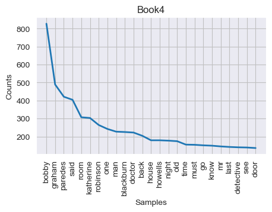

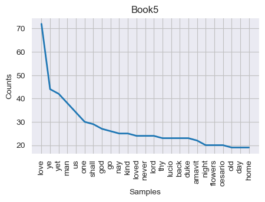

```python
plt.figure(figsize=(5,3))
book4_features['frequent words'].plot(25, title='Book4')
plt.figure(figsize=(5,3))
book5_features['frequent words'].plot(25, title='Book5')
```

The terms "thy," "love," and "lord," which are some of the most frequently used in Book 5, suggest that the book is likely a poem connected to the aforementioned thread. And the word count is also relatively less in the book. However, the words "detective" and "time" in book 4 lead us to believe that the book is in the detective or mystery genre, and a few names, such as "Bobby," "Graham," and "Katherine," stand out as possible characters of the book.

#### Q4 continued - It would also be intriguing to look at the relationships between the often occurring word combinations in the list and how they are used in the text.

The word pairs may be extremely helpful in the analysis since they will give a better context for the most often used terms, as some word pairs occur more frequently than others, and more insightful information can be drawn about the book's qualities from the analysis. The frequent bigrams gathered and stored in the book features is graphically represented to analyse the word pairs.

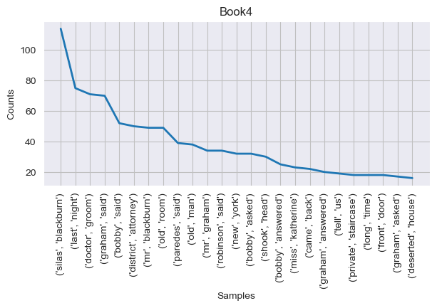

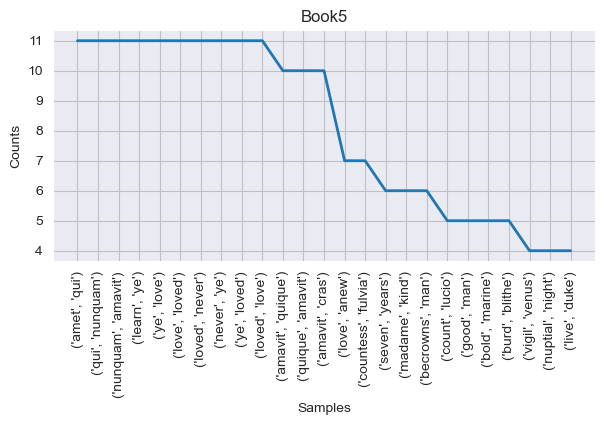

```python
plt.figure(figsize=(7,3))
book4_features['frequent bigrams'].plot(25, title='Book4')
plt.figure(figsize=(7,3))
book5_features['frequent bigrams'].plot(25, title='Book5')
```

#### Q5 continued - Evaluating the complexity of the literature will be a fascinating aspect of the analysis, as it could contribute to a better understanding of people, experiences and culture in the author's era.

The complexity in the writing is based on the phrases and descriptives used in the book, hence comparing the complexity of books from different author reveals the difference in the underlying writing style.

```python
print(f'The lexical density of Book 4 is : {lex_density(10869)}')
print(f'The lexical density of Book 5 is : {lex_density(10133)}')
```

```
The lexical density of Book 4 is : 17.140112896144906
The lexical density of Book 5 is : 15.576508036026476
```

[figure not shown]

```python
lex_density_dict_ph2 = {'book4' : lex_density(10562), 'book5': lex_density(10783)}

fig, ax = plt.subplots(figsize=(6, 4))
ax.plot(lex_density_dict_ph2.keys(), lex_density_dict_ph2.values())
ax.scatter(lex_density_dict_ph2.keys(), lex_density_dict_ph2.values())
ax.set_ylabel('lexical density score')
```

Relative to book 4, which is a mystery thriller, as we discovered through earlier research, book 5 is less complicated. In comparison to a thriller, the fifth book appears to be a poem.

#### Q6 continued - Can we identify and compare the sentiment score and emotions in the book written by different authors?

The sentiment score, which was addressed in Part II, offers us a broad picture of how favourable or unfavourable the book's context is. Emotions, on the other hand, are a factor that influences how profound and significant the writing turns out to be and contributes in creating a connection between the writer and their readers. Therefore, it is essential to compare the sentiment score as well as emotion scores of different authors in order to comprehend their variances. The functions of sentiment analysis has been used to evaluate the polarity score.

```python
senti_score_book4 = sentiment_polarity_score(10869)
print(f'The sentiment score of Book 4 is : {senti_score_book4}')

senti_score_book5 = sentiment_polarity_score(10133)
print(f'The sentiment score of Book 5 is : {senti_score_book5}')
```

```
The sentiment score of Book 4 is : {'neg': 0.125, 'neu': 0.783, 'pos': 0.092, 'compound': -1.0}
The sentiment score of Book 5 is : {'neg': 0.081, 'neu': 0.762, 'pos': 0.156, 'compound': 1.0}
```

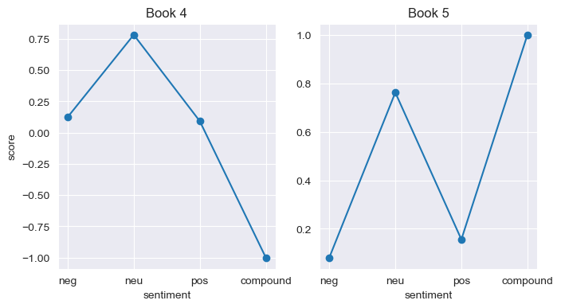

```python
fig = plt.figure(figsize=(12, 4))

plt.subplot(131)
plt.plot(senti_score_book4.keys(), senti_score_book4.values())
plt.scatter(senti_score_book4.keys(), senti_score_book4.values())
plt.title('Book 4')
plt.xlabel('sentiment')
plt.ylabel('score')

plt.subplot(132)
plt.plot(senti_score_book5.keys(), senti_score_book5.values())
plt.scatter(senti_score_book5.keys(), senti_score_book5.values())
plt.title('Book 5')
plt.xlabel('sentiment')
plt.show()
```

While the two books are compared, Book 4 has a sentiment score of -1, indicating a negative context, while Book 5 has a sentiment score of +1, indicating a positive one. The same results can be seen when looking at both neg and pos values changes. Consequently, it can be said that Book 4 is more oriented toward a negative perspective than Book 5 is.

```python
emotion_check_book4 = (cleaned_data(10869)[-20000:])
emotion_book4 = te.get_emotion(emotion_check_book4)
print(f'The emotion score of Book 4 is: {emotion_book4}')

emotion_check_book5 = (cleaned_data(10133)[-20000:])
emotion_book5 = te.get_emotion(emotion_check_book5)
print(f'The emotion score of Book 5 is: {emotion_book5}')
```

```
The emotion score of Book 4 is: {'Happy': 0.09, 'Angry': 0.07, 'Surprise': 0.18, 'Sad': 0.28, 'Fear': 0.39}
The emotion score of Book 5 is: {'Happy': 0.16, 'Angry': 0.11, 'Surprise': 0.18, 'Sad': 0.25, 'Fear': 0.3}
```

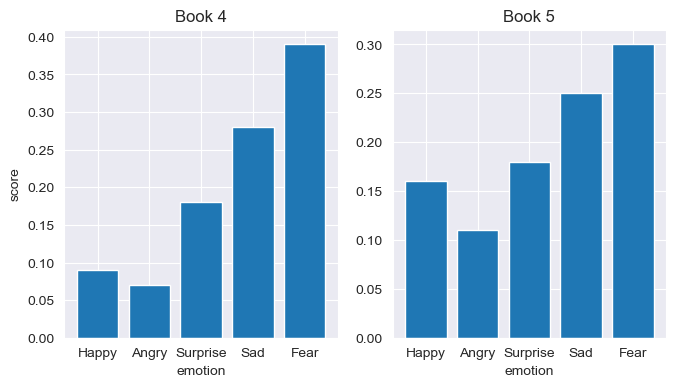

```python
fig = plt.figure(figsize=(12, 4))

plt.subplot(131)
plt.bar(emotion_book4.keys(), emotion_book4.values())
plt.title('Book 4')
plt.xlabel('emotion')
plt.ylabel('score')

plt.subplot(132)
plt.bar(emotion_book5.keys(), emotion_book5.values())
plt.title('Book 5')
plt.xlabel('emotion')
plt.show()
```

#### Q7 continued - Finding out how different authors' text similarities turn out might be intriguing.

The authors Wadsworth Camp, W.W Jacobs, and Arthur Quiller-Couch must have different writing styles and genres, comparing and analysing the similarities between the three must provide some insight into their writing style. As in phase II-A, the spacy NLP library has been employed and same functions has been used to find the similarity in the texts.

```python
book4_sent = nlp(cleaned_data(10869))
book5_sent = nlp(cleaned_data(10133))

print(f'The similarity score between Book 4 and Book 5 is : {book5_sent.similarity(book4_sent)}')
print(f'The similarity between Book 2 and Book 5 is: {book2_sent.similarity(book5_sent)}')
print(f'The similarity of nouns used in Book 2 and Book 5 is: {get_noun(book2_sent).similarity(get_noun(book5_sent))}')
```

```
The similarity score between Book 4 and Book 5 is : 0.9543188678683777
The similarity between Book 2 and Book 5 is: 0.8930329085972927
The similarity of nouns used in Book 2 and Book 5 is: 0.8820330354079743
```

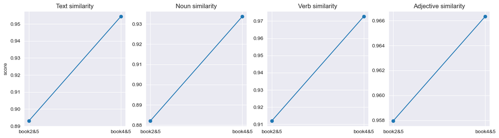

```python
noun_similarity_ph2 = {'book2&5': get_noun(book2_sent).similarity(get_noun(book5_sent)),
                       'book4&5': get_noun(book4_sent).similarity(get_noun(book5_sent))}

verb_similarity_ph2 = {'book2&5': get_verb(book2_sent).similarity(get_verb(book5_sent)),
                       'book4&5': get_verb(book4_sent).similarity(get_verb(book5_sent))}

adj_similarity_ph2 = {'book2&5': get_adj(book2_sent).similarity(get_adj(book5_sent)),
                      'book4&5': get_adj(book4_sent).similarity(get_adj(book5_sent))}

text_similarity_ph2 = {'book2&5': book2_sent.similarity(book5_sent), 'book4&5': book5_sent.similarity(book4_sent)}

fig, ax = plt.subplots(1, 4, figsize=(16, 4))

ax[0].plot(text_similarity_ph2.keys(), text_similarity_ph2.values())
ax[0].scatter(text_similarity_ph2.keys(), text_similarity_ph2.values())
ax[0].set_title('Text similarity')
ax[0].set_ylabel('score')

ax[1].plot(noun_similarity_ph2.keys(), noun_similarity_ph2.values())
ax[1].scatter(noun_similarity_ph2.keys(), noun_similarity_ph2.values())
ax[1].set_title('Noun similarity')

ax[2].plot(verb_similarity_ph2.keys(), verb_similarity_ph2.values())
ax[2].scatter(verb_similarity_ph2.keys(), verb_similarity_ph2.values())
ax[2].set_title('Verb similarity')

ax[3].plot(adj_similarity_ph2.keys(), adj_similarity_ph2.values())
ax[3].scatter(adj_similarity_ph2.keys(), adj_similarity_ph2.values())
ax[3].set_title('Adjective similarity')
```

The similarity score between books by two distinct authors is relatively outstanding, being 0.893 between books 2 & 5, but only 0.95 between books 4 & 5, showing a change in genre and writing style. When comparing books 2, 4, and 5, books 4 & 5 are more comparable than books 2 & 5, suggesting that the books may share more descriptions and phrases. The similarity score between the nouns used in Books 2 & 5 also reveals the genre of the work because there is a clear distinction between the vocabulary used in fiction and poetry. Additionally, it demonstrates that when comparing books 2 and 5, the verb and adjective scores appear to be distinct, whereas the text similarity score is close to the noun similarity.

These numerical values aid in comparing the literature works and, at a better elevation, can be used to train the data further in a machine-learning model rather than actual textual data.

## Suggestions

- The writing style, characters, narrative, and context of the books in our dataset (which are from the Victorian or Edwardian era) from the span 1800s to the early 1900s, can be utilized to shed light on how literature has changed through the time. The actual publishing date is dispersed across the data, making it difficult to sort, which inhibits our ability to analyse the data based on time. Consequently, the dateutil.parser module or more sophisticated algorithms may be employed to search for the book's actual year of publication to achieve the aforementioned findings.
- Apart from analysing old literature and the evolution of literature evaluation, data from our analysis may be applied to more recent works, which can be used to further develop a model that predicts the topics of the author's future books. The topics can be predicted using algorithms like Support Vector Machine (SVM), which excels in categorical data analysis and pattern recognition.
- Furthermore, as readers tend to select a particular genre, book length, author of the book they have read before, and so on, our evaluations can also be modified to a predictor to predict a book's sales before its publication, if additional information, such as the publisher, price, previous sales of the books, and the month the book was sold, is presented along with our data. The future success or failure of the book's sales can be predicted by using logistic regression, which divides data into the classifications of (0) or (1) based on multiple predictor variables. In addition, Random Forest can be used to forecast a sale's success or failure because it uses multiple trees and selects the majority as the best value, producing the optimal result. Additionally, the article [11] has specifics about a statistical model developed to recognise and forecast a pattern in book sales, that can be incorporated into our book sales prediction.

## Bibliography

[1] https://www.gutenberg.org/ebooks/69478  
[2] https://pynative.com/python-regex-search/#:~:text=Python%20regex%20re.search(),pattern%20from%20the%20target%20string  
[3] https://docs.python.org/3/library/re.html  
[4] https://python.plainenglish.io/a-quick-trick-to-make-dataframes-with-uneven-array-lengths-32bf80d8a61d  
[5] https://towardsdatascience.com/text2emotion-python-package-to-detect-emotions-from-textual-data-b2e7b7ce1153#:~:text=Text2emotion%20works%2C%20in%20the%20same,the%20form%20of%20a%20dictionary  
[6] https://stackoverflow.com/questions/52113939/spacy-strange-similarity-between-two-sentences  
[7] https://spacy.io/usage/linguistic-features  
[8] https://www.geeksforgeeks.org/removing-stop-words-nltk-python/  
[9] https://www.geeksforgeeks.org/python-string-isalpha-method/  
[10] https://numpy.org/devdocs/user/absolute_beginners.html  
[11] Yucesoy, B., Wang, X., Huang, J., & Barabási, A. (2018). Success in books: a big data approach to bestsellers. EPJ Data Science, 7(1), 1-25. https://doi.org/10.1140/epjds/s13688-018-0135-y